# Exploration of the Ford GoBike System Data

## Preliminary Wrangling

This dataset is from Lyft Bay Wheel. (source: https://www.lyft.com/bikes/bay-wheels/system-data) It includes information about individual rides made in a bike-sharing system covering the greater San Francisco Bay area. Each trip is anonymized and includes:

- Start Time and Date
- End Time and Date
- Start Station ID
- Start Station Name
- Start Station Latitude
- Start Station Longitude
- End Station ID
- End Station Name
- End Station Latitude
- End Station Longitude
- User Type (Subscriber or Customer – “Subscriber” = Member or “Customer” = Casual)

and other variables.

I am going to explore the following issues with this dataset:

1. When are most trips taken in terms of time of day, day of the week, or month of the year?
2. How long does the average trip take?
3. Does the above depend on if a user is a subscriber or customer?

I manually download 18 months data from the website, from Jan 2019 to Jun 2020. Before I start the exploration, I need first clean and tidy the data:

- The variable names are not consistent, which I need correct.
- The raw data have 18 separate tables; I need combine them together.
- The labels in `user_type` are not consistent.

```python
# import all packages and set plots to be embedded inline
import numpy as np
import pandas as pd
import matplotlib.pyplot as plt
import seaborn as sb
import missingno # plotting missing data

import glob
import os
import re
%matplotlib inline
```

```python
csv_list = sorted(glob.glob('data/*data.csv'))
df_list  = []

for path in csv_list:
    print('loading', path[5:])

    ym  = re.findall('\d+', path)[0]
    tmp = pd.read_csv(path,
                      dtype={'user_type':'string',
                             'bike_share_for_all_trip':'string',
                             'rental_access_method':'string'})
    exec('df_{} = tmp.copy()'.format(ym))
    exec('df_list.append(df_{})'.format(ym))

    print('done! data size:', tmp.shape, '\n')
```

```
loading 201901-fordgobike-tripdata.csv
done! data size: (192082, 14)

loading 201902-fordgobike-tripdata.csv
done! data size: (183412, 14)

loading 201903-fordgobike-tripdata.csv
done! data size: (256299, 14)

loading 201904-fordgobike-tripdata.csv
done! data size: (239111, 14)

loading 201905-baywheels-tripdata.csv
done! data size: (182163, 14)

loading 201906-baywheels-tripdata.csv
done! data size: (191772, 15)

loading 201907-baywheels-tripdata.csv
done! data size: (258102, 15)

loading 201908-baywheels-tripdata.csv
done! data size: (210563, 14)

loading 201909-baywheels-tripdata.csv
done! data size: (217986, 14)

loading 201910-baywheels-tripdata.csv
done! data size: (239895, 14)

loading 201911-baywheels-tripdata.csv
done! data size: (185496, 15)

loading 201912-baywheels-tripdata.csv
done! data size: (150102, 14)

loading 202001-baywheels-tripdata.csv
done! data size: (295854, 14)

loading 202002-baywheels-tripdata.csv
done! data size: (432354, 14)

loading 202003-baywheels-tripdata.csv
done! data size: (176799, 14)

loading 202004-baywheels-tripdata.csv
done! data size: (84259, 13)

loading 202005-baywheels-tripdata.csv
done! data size: (138251, 14)

loading 202006-baywheels-tripdata.csv
done! data size: (158168, 13)
```

```python
for i in range(len(df_list)):
    var_list = df_list[i].columns.values
    for j in range(len(var_list)):
        print(var_list[j][0:4], end=' ')
    print()
```

```
dura star end_ star star star star end_ end_ end_ end_ bike user bike
dura star end_ star star star star end_ end_ end_ end_ bike user bike
dura star end_ star star star star end_ end_ end_ end_ bike user bike
dura star end_ star star star star end_ end_ end_ end_ bike user bike
dura star end_ star star star star end_ end_ end_ end_ bike user bike
dura star end_ star star star star end_ end_ end_ end_ bike user bike rent
dura star end_ star star star star end_ end_ end_ end_ bike user bike rent
dura star end_ star star star star end_ end_ end_ end_ bike user bike
dura star end_ star star star star end_ end_ end_ end_ bike user bike
dura star end_ star star star star end_ end_ end_ end_ bike user bike
dura star end_ star star star star end_ end_ end_ end_ bike user bike rent
dura star end_ star star star star end_ end_ end_ end_ bike user rent
dura star end_ star star star star end_ end_ end_ end_ bike user rent
dura star end_ star star star star end_ end_ end_ end_ bike user rent
dura star end_ star star star star end_ end_ end_ end_ bike user rent
ride ride star ende star star end_ end_ star star end_ end_ memb
ride ride star ende star star end_ end_ star star end_ end_ memb is_e
ride ride star ende star star end_ end_ star star end_ end_ memb
```

```python
df_list[5].head()
```

|  | duration_sec | start_time | end_time | start_station_id | start_station_name | start_station_latitude | start_station_longitude | end_station_id | end_station_name | end_station_latitude | end_station_longitude | bike_id | user_type | bike_share_for_all_trip | rental_access_method |
| --- | --- | --- | --- | --- | --- | --- | --- | --- | --- | --- | --- | --- | --- | --- | --- |
| 0 | 81695 | 2019-06-30 18:16:09.7730 | 2019-07-01 16:57:45.5920 | 109.0 | 17th St at Valencia St | 37.763316 | -122.421904 | 56.0 | Koshland Park | 37.773414 | -122.427317 | 1502 | Subscriber | No | <NA> |
| 1 | 74260 | 2019-06-30 18:09:55.8300 | 2019-07-01 14:47:36.6810 | 50.0 | 2nd St at Townsend St | 37.780526 | -122.390288 | 101.0 | 15th St at Potrero Ave | 37.767079 | -122.407359 | 2526 | Customer | No | <NA> |
| 2 | 59603 | 2019-06-30 15:40:31.0380 | 2019-07-01 08:13:54.3490 | 23.0 | The Embarcadero at Steuart St | 37.791464 | -122.391034 | 30.0 | San Francisco Caltrain (Townsend St at 4th St) | 37.776598 | -122.395282 | 2427 | Subscriber | No | <NA> |
| 3 | 67932 | 2019-06-30 12:49:47.7810 | 2019-07-01 07:42:00.5430 | 169.0 | Bushrod Park | 37.846516 | -122.265304 | 248.0 | Telegraph Ave at Ashby Ave | 37.855956 | -122.259795 | 1261 | Customer | No | <NA> |
| 4 | 48894 | 2019-06-30 17:21:00.0550 | 2019-07-01 06:55:54.9960 | 15.0 | San Francisco Ferry Building (Harry Bridges Pl... | 37.795392 | -122.394203 | 30.0 | San Francisco Caltrain (Townsend St at 4th St) | 37.776598 | -122.395282 | 1070 | Customer | No | <NA> |

```python
df_list[-2].head()
```

|  | ride_id | rideable_type | started_at | ended_at | start_station_name | start_station_id | end_station_name | end_station_id | start_lat | start_lng | end_lat | end_lng | member_casual | is_equity |
| --- | --- | --- | --- | --- | --- | --- | --- | --- | --- | --- | --- | --- | --- | --- |
| 0 | BA4B4D93677877E8 | electric_bike | 2020-05-18 22:16:06 | 2020-05-18 22:28:20 | NaN | NaN | NaN | NaN | 37.3443 | -121.9218 | 37.3443 | -121.9217 | casual | False |
| 1 | 92634E825C7303CC | electric_bike | 2020-05-19 16:57:35 | 2020-05-19 17:29:56 | NaN | NaN | NaN | NaN | 37.7286 | -122.4921 | 37.7154 | -122.4854 | casual | False |
| 2 | 1FCDD14C62521CC1 | electric_bike | 2020-05-18 20:08:14 | 2020-05-18 20:14:25 | NaN | NaN | Webster St at Clay St | 492.0 | 37.7919 | -122.4174 | 37.7906 | -122.4325 | casual | False |
| 3 | 3A5CEC684CA9FA18 | electric_bike | 2020-05-19 14:05:08 | 2020-05-19 14:14:16 | NaN | NaN | NaN | NaN | 37.7557 | -122.4165 | 37.7681 | -122.4266 | casual | False |
| 4 | 1FF95A9C2D1ED7F8 | electric_bike | 2020-05-10 17:45:54 | 2020-05-10 18:29:29 | Pier 1/2 at The Embarcadero | 12.0 | NaN | NaN | 37.7964 | -122.3946 | 37.7780 | -122.4144 | casual | False |

```python
df_list[-2].rideable_type.value_counts()
```

```
electric_bike    94251
docked_bike      44000
Name: rideable_type, dtype: int64
```

```python
df_list[-3].member_casual.value_counts()
```

```
casual    46030
member    38229
Name: member_casual, dtype: int64
```

```python
df_list[-5].user_type.value_counts()
```

```
Subscriber    277446
Customer      154908
Name: user_type, dtype: Int64
```

```python
df_list[0].columns.values
```

```
array(['duration_sec', 'start_time', 'end_time', 'start_station_id',
       'start_station_name', 'start_station_latitude',
       'start_station_longitude', 'end_station_id', 'end_station_name',
       'end_station_latitude', 'end_station_longitude', 'bike_id',
       'user_type', 'bike_share_for_all_trip'], dtype=object)
```

```python
df_list[-1].columns.values
```

```
array(['ride_id', 'rideable_type', 'started_at', 'ended_at',
       'start_station_name', 'start_station_id', 'end_station_name',
       'end_station_id', 'start_lat', 'start_lng', 'end_lat', 'end_lng',
       'member_casual'], dtype=object)
```

```python
var_list_1 = ['start_time', 'end_time',
              'start_station_id', 'start_station_name',
              'end_station_id',   'end_station_name',
              'start_station_latitude', 'start_station_longitude',
              'end_station_latitude',   'end_station_longitude',
              'user_type']
var_list_2 = ['started_at', 'ended_at',
              'start_station_id', 'start_station_name',
              'end_station_id',   'end_station_name',
              'start_lat', 'start_lng', 'end_lat', 'end_lng',
              'member_casual']
```

```python
df_main = pd.DataFrame()
for i in range(15):
    tmp = df_list[i][var_list_1].rename({'start_station_latitude':'start_lat',
                                         'start_station_longitude':'start_lng',
                                         'end_station_latitude':'end_lat',
                                         'end_station_longitude':'end_lng'}, axis=1)
    df_main = df_main.append(tmp, ignore_index=True)

for i in range(15,18):
    tmp = df_list[i][var_list_2].rename(columns = {'started_at':'start_time',
                                                   'ended_at':  'end_time',
                                                   'member_casual':'user_type'})
    df_main = df_main.append(tmp, ignore_index=True)
```

```python
df_main.head()
```

|  | start_time | end_time | start_station_id | start_station_name | end_station_id | end_station_name | start_lat | start_lng | end_lat | end_lng | user_type |
| --- | --- | --- | --- | --- | --- | --- | --- | --- | --- | --- | --- |
| 0 | 2019-01-31 17:57:44.6130 | 2019-02-01 16:24:49.8640 | 229.0 | Foothill Blvd at 42nd Ave | 196.0 | Grand Ave at Perkins St | 37.775745 | -122.213037 | 37.808894 | -122.256460 | Subscriber |
| 1 | 2019-01-31 20:58:33.8860 | 2019-02-01 15:16:54.1730 | 4.0 | Cyril Magnin St at Ellis St | 134.0 | Valencia St at 24th St | 37.785881 | -122.408915 | 37.752428 | -122.420628 | Subscriber |
| 2 | 2019-01-31 18:06:52.9240 | 2019-02-01 11:30:46.5300 | 245.0 | Downtown Berkeley BART | 157.0 | 65th St at Hollis St | 37.870139 | -122.268422 | 37.846784 | -122.291376 | Customer |
| 3 | 2019-01-31 19:46:09.7190 | 2019-02-01 08:10:50.3180 | 85.0 | Church St at Duboce Ave | 53.0 | Grove St at Divisadero | 37.770083 | -122.429156 | 37.775946 | -122.437777 | Customer |
| 4 | 2019-01-31 14:19:01.5410 | 2019-02-01 07:10:51.0650 | 16.0 | Steuart St at Market St | 28.0 | The Embarcadero at Bryant St | 37.794130 | -122.394430 | 37.787168 | -122.388098 | Customer |

```python
df_main.info(null_counts=True)
```

```
<class 'pandas.core.frame.DataFrame'>
RangeIndex: 3792668 entries, 0 to 3792667
Data columns (total 11 columns):
 #   Column              Non-Null Count    Dtype
---  ------              --------------    -----
 0   start_time          3792668 non-null  object
 1   end_time            3792668 non-null  object
 2   start_station_id    3084923 non-null  float64
 3   start_station_name  3086757 non-null  object
 4   end_station_id      3077094 non-null  float64
 5   end_station_name    3078920 non-null  object
 6   start_lat           3792668 non-null  float64
 7   start_lng           3792668 non-null  float64
 8   end_lat             3792026 non-null  float64
 9   end_lng             3792026 non-null  float64
 10  user_type           3792668 non-null  object
dtypes: float64(6), object(5)
memory usage: 318.3+ MB
```

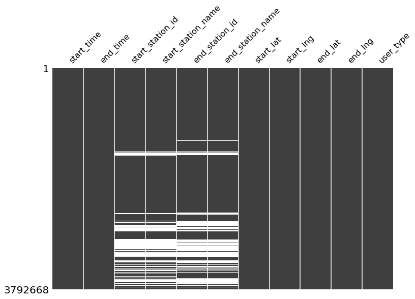

```python
missingno.matrix(df_main, sparkline=False, figsize=(12,8));
```

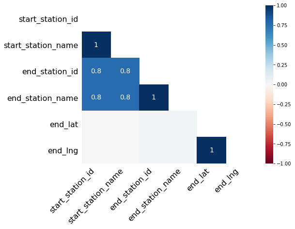

```python
missingno.heatmap(df_main, figsize=(8,6));
```

```python
df_main.user_type.value_counts()
```

```
Subscriber    2565862
Customer       846128
casual         226098
member         154580
Name: user_type, dtype: int64
```

```python
df_main['user_type'] = df_main.user_type.replace({'casual':'Customer','member':'Subscriber'})
df_main.user_type.value_counts()
```

```
Subscriber    2720442
Customer      1072226
Name: user_type, dtype: int64
```

Now we have finished the data wrangling step.

```python
df = df_main.drop(columns=['start_station_id','start_station_name','end_station_id','end_station_name'])
df.to_csv('./data/clean.csv', index=False)
```

## Load data

```python
df = pd.read_csv('./data/clean.csv')
df.head()
```

|  | start_time | end_time | start_lat | start_lng | end_lat | end_lng | user_type |
| --- | --- | --- | --- | --- | --- | --- | --- |
| 0 | 2019-01-31 17:57:44.6130 | 2019-02-01 16:24:49.8640 | 37.775745 | -122.213037 | 37.808894 | -122.256460 | Subscriber |
| 1 | 2019-01-31 20:58:33.8860 | 2019-02-01 15:16:54.1730 | 37.785881 | -122.408915 | 37.752428 | -122.420628 | Subscriber |
| 2 | 2019-01-31 18:06:52.9240 | 2019-02-01 11:30:46.5300 | 37.870139 | -122.268422 | 37.846784 | -122.291376 | Customer |
| 3 | 2019-01-31 19:46:09.7190 | 2019-02-01 08:10:50.3180 | 37.770083 | -122.429156 | 37.775946 | -122.437777 | Customer |
| 4 | 2019-01-31 14:19:01.5410 | 2019-02-01 07:10:51.0650 | 37.794130 | -122.394430 | 37.787168 | -122.388098 | Customer |

```python
df.info(null_counts=True)
```

```
<class 'pandas.core.frame.DataFrame'>
RangeIndex: 3792668 entries, 0 to 3792667
Data columns (total 7 columns):
 #   Column      Non-Null Count    Dtype
---  ------      --------------    -----
 0   start_time  3792668 non-null  object
 1   end_time    3792668 non-null  object
 2   start_lat   3792668 non-null  float64
 3   start_lng   3792668 non-null  float64
 4   end_lat     3792026 non-null  float64
 5   end_lng     3792026 non-null  float64
 6   user_type   3792668 non-null  object
dtypes: float64(4), object(3)
memory usage: 202.6+ MB
```

```python
df['start_time'] = pd.to_datetime(df.start_time)
df['end_time']   = pd.to_datetime(df.end_time)
```

```python
df.dtypes
```

```
start_time    datetime64[ns]
end_time      datetime64[ns]
start_lat            float64
start_lng            float64
end_lat              float64
end_lng              float64
user_type             object
dtype: object
```

### What is the structure of your dataset?

The data contains the following variables

- `start_time`: starting time of the trip
- `end_time`: ending time of the trip
- `start_lat`: latitude of the starting location
- `start_lng`: longitude of the starting location
- `end_lat`: latitude of the ending location
- `end_lng`: longitude of the ending location
- `user_type`: type of user, either subscriber or non-subscriber

### What is/are the main feature(s) of interest in your dataset?

The dataset contains detailed geographic information for each trip, i.e., the starting location and ending location. Also, the trip start time and end time can provide rich information on travel time.

### What features in the dataset do you think will help support your investigation into your feature(s) of interest?

I am gonna explore the following three questions with this dataset:

1. When are most trips taken in terms of time of day, day of the week, or month of the year?
2. How long does the average trip take?
3. Does the above depend on if a user is a subscriber or customer?

Features such as `start_time`, `end_time`, `start_lat`, `start_lng`, `end_lat`, and `end_lng` will help me directly address these questions.

## Univariate Exploration

> In this section, investigate distributions of individual variables. If you see unusual points or outliers, take a deeper look to clean things up and prepare yourself to look at relationships between variables.

Let's first explore the trip distribution in terms of time of day.

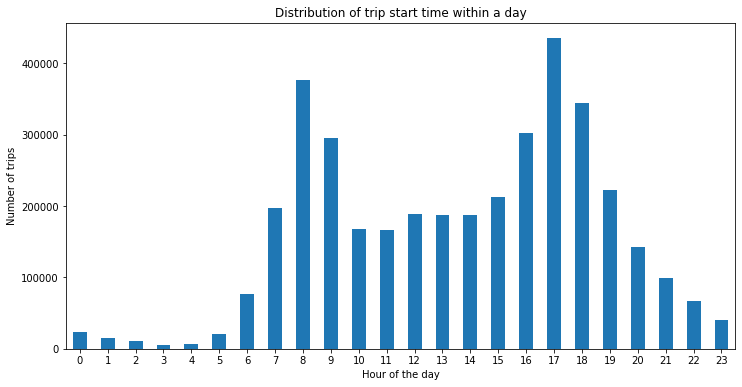

```python
plt.figure(figsize=(12,6))
df.start_time.dt.hour.value_counts().sort_index().plot(kind='bar')
plt.xticks(rotation=0)
plt.ylabel('Number of trips')
plt.xlabel('Hour of the day')
plt.title('Distribution of trip start time within a day');
```

It can be seen that most trips occured during 7-9am and 4-6pm. This pattern makes perfect sense as they correspond to the time going to workplace and the time going back home.

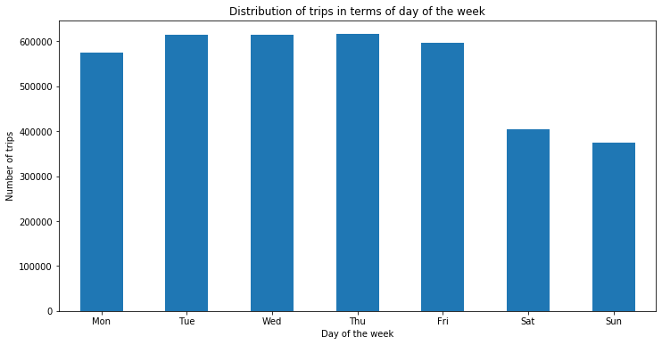

```python
plt.figure(figsize=(12,6))
df.start_time.dt.weekday.value_counts().sort_index().plot(kind='bar')
plt.xticks(range(7), ['Mon','Tue','Wed','Thu','Fri','Sat','Sun'], rotation=0)
plt.ylabel('Number of trips')
plt.xlabel('Day of the week')
plt.title('Distribution of trips in terms of day of the week');
```

As we can see from the graph above, less trip occured on weekends.

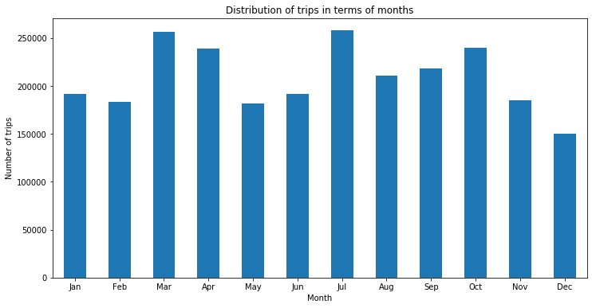

```python
plt.figure(figsize=(12,6))
df.query('start_time < "2020-01-01"').start_time.dt.month.value_counts().sort_index().plot(kind='bar')
plt.xticks(range(12), ['Jan','Feb','Mar','Apr','May','Jun','Jul','Aug','Sep','Oct','Nov','Dec'], rotation=0)
plt.ylabel('Number of trips')
plt.xlabel('Month')
plt.title('Distribution of trips in terms of months');
```

I only used the data of year 2019. It seems there is no clear pattern. December has less trips probably because of the christmas holiday. We should be cautious about the monthly pattern we get above for the folloing two reasons:

- Since I only consider one year, some months may be subject to special shocks/events and hence does not reflect the true pattern.
- If the business is still growing, then this pattern may incorporate some growing trend and hence does not reflec the true pattern.

So far, we have finished exploring question 1.

Next, let's take look at the distribution of trip duration and explore question 2.

```python
df['duration'] = (df.end_time - df.start_time).dt.total_seconds()/60
df.duration.describe() # unit: minute
```

```
count    3.792668e+06
mean     1.506061e+01
std      1.256271e+02
min     -5.315245e+01
25%      6.116667e+00
50%      9.866667e+00
75%      1.564307e+01
max      5.472887e+04
Name: duration, dtype: float64
```

```python
df.duration.quantile(0.005)
```

```
1.2
```

```python
df.duration.quantile(0.995)
```

```
118.8673649166667
```

```python
df_trim = df.query('duration > 1.2')
df_trim = df_trim.query('duration < 120')
```

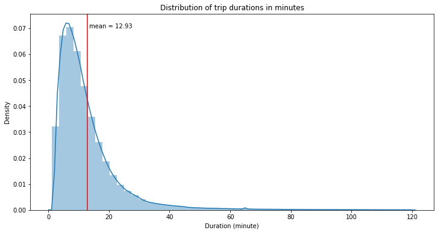

```python
avg_time = df_trim.duration.mean()
plt.figure(figsize=(12,6))
sb.distplot(df_trim.duration)
plt.axvline(x=avg_time, color='r')
plt.text(avg_time, 0.07,' mean = {:.2f}'.format(avg_time))
plt.xlabel('Duration (minute)')
plt.ylabel('Density')
plt.title('Distribution of trip durations in minutes');
```

```python
(df_trim.duration < 30).mean()
```

```
0.9410276048704389
```

It can be seen that the average trip time is about 13 mins. Almost 95% of the trips took less than half an hour. However, the distribution has a very fat tail. Question 2 finished.

## Bivariate Exploration

In this section, we are going to revisit question 1 and 2 by focusing on different types of users.

```python
df_trim.user_type.value_counts()
```

```
Subscriber    2706106
Customer      1048956
Name: user_type, dtype: int64
```

```python
df_trim
```

|  | start_time | end_time | start_lat | start_lng | end_lat | end_lng | user_type | duration |
| --- | --- | --- | --- | --- | --- | --- | --- | --- |
| 5 | 2019-01-31 22:35:50.813 | 2019-02-01 00:28:04.512 | 37.870139 | -122.268422 | 37.862464 | -122.264791 | Subscriber | 112.228317 |
| 6 | 2019-01-31 23:54:38.901 | 2019-02-01 00:14:27.900 | 37.783988 | -122.412408 | 37.742314 | -122.423181 | Subscriber | 19.816650 |
| 7 | 2019-01-31 23:48:50.092 | 2019-02-01 00:09:44.497 | 37.330698 | -121.888979 | 37.333988 | -121.894902 | Subscriber | 20.906750 |
| 8 | 2019-01-31 23:17:05.462 | 2019-02-01 00:09:39.457 | 37.782405 | -122.439446 | 37.773311 | -122.444293 | Subscriber | 52.566583 |
| 9 | 2019-01-31 23:59:47.568 | 2019-02-01 00:05:11.177 | 37.764765 | -122.420091 | 37.758862 | -122.412544 | Subscriber | 5.393483 |
| ... | ... | ... | ... | ... | ... | ... | ... | ... |
| 3792663 | 2020-06-03 17:36:00.000 | 2020-06-03 17:48:03.000 | 37.766218 | -122.431059 | 37.773507 | -122.416040 | Customer | 12.050000 |
| 3792664 | 2020-06-09 16:11:52.000 | 2020-06-09 16:22:46.000 | 37.828409 | -122.266314 | 37.838800 | -122.258732 | Customer | 10.900000 |
| 3792665 | 2020-06-20 21:23:17.000 | 2020-06-20 21:38:26.000 | 37.812314 | -122.260778 | 37.812314 | -122.260779 | Customer | 15.150000 |
| 3792666 | 2020-06-13 11:40:08.000 | 2020-06-13 11:55:17.000 | 37.849594 | -122.265568 | 37.844279 | -122.251900 | Customer | 15.150000 |
| 3792667 | 2020-06-23 19:33:38.000 | 2020-06-23 19:45:56.000 | 37.769094 | -122.386332 | 37.782926 | -122.387921 | Customer | 12.300000 |

3755062 rows × 8 columns

```python
df_trim['hour'] = df_trim.start_time.dt.hour
df_trim['day'] = df_trim.start_time.dt.weekday
df_trim['month'] = df_trim.start_time.dt.month
```

```python
by_hour = df_trim.groupby(['user_type'])['hour'].value_counts(normalize=True).rename('percentage').reset_index()
by_hour.head()
```

|  | user_type | hour | percentage |
| --- | --- | --- | --- |
| 0 | Customer | 17 | 0.110084 |
| 1 | Customer | 18 | 0.089721 |
| 2 | Customer | 16 | 0.084609 |
| 3 | Customer | 8 | 0.077503 |
| 4 | Customer | 15 | 0.069889 |

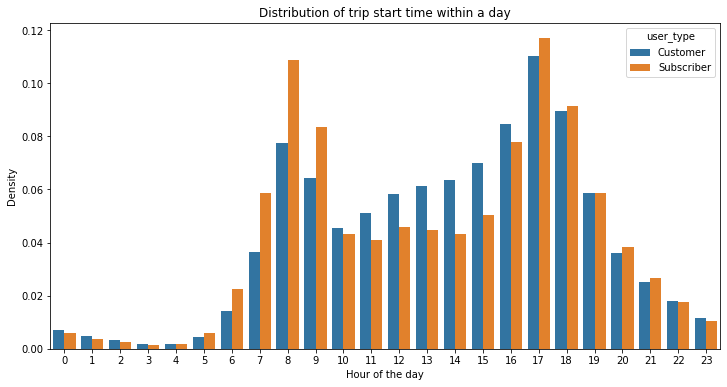

```python
plt.figure(figsize=(12,6))
sb.barplot(x="hour", y='percentage', hue='user_type', data=by_hour)
plt.ylabel('Density')
plt.xlabel('Hour of the day')
plt.title('Distribution of trip start time within a day');
```

It seems subscribers take more trips during peak hours than customers. This makes sense as rugular riders are more inclined to subscribe.

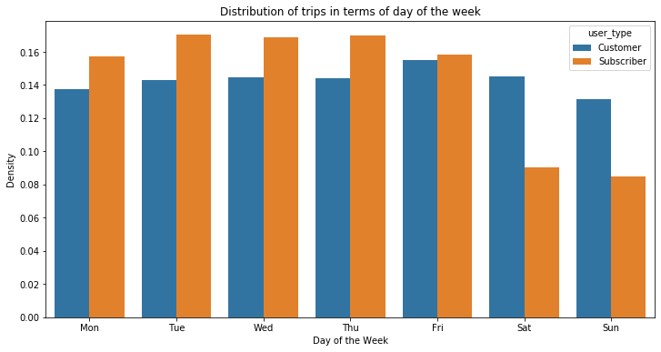

```python
by_day = df_trim.groupby(['user_type'])['day'].value_counts(normalize=True).rename('percentage').reset_index()

plt.figure(figsize=(12,6))
sb.barplot(x="day", y='percentage', hue='user_type', data=by_day)
plt.ylabel('Density')
plt.xlabel('Day of the Week')
plt.title('Distribution of trips in terms of day of the week')
plt.xticks(range(7), ['Mon','Tue','Wed','Thu','Fri','Sat','Sun'], rotation=0);
```

We can again tell the difference between the two groups: subscribers tend to make more trips during weekdays than customers. People who rugularly ride bike to work are more likely to become a subscriber, and thus they are more active on weekdays.

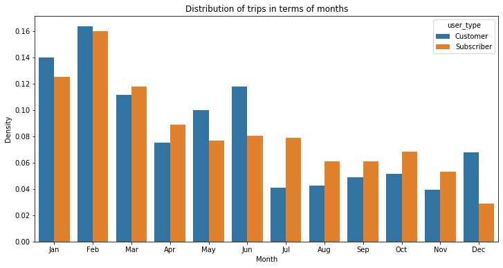

```python
by_month = df_trim.groupby(['user_type'])['month'].value_counts(normalize=True).rename('percentage').reset_index()

plt.figure(figsize=(12,6))
sb.barplot(x="month", y='percentage', hue='user_type', data=by_month)
plt.xticks(range(12), ['Jan','Feb','Mar','Apr','May','Jun','Jul','Aug','Sep','Oct','Nov','Dec'], rotation=0)
plt.ylabel('Density')
plt.xlabel('Month')
plt.title('Distribution of trips in terms of months');
```

The demand pattern for subscribers is less volatile than customers except for December. Again, this is because subscribers have a more stable demand.

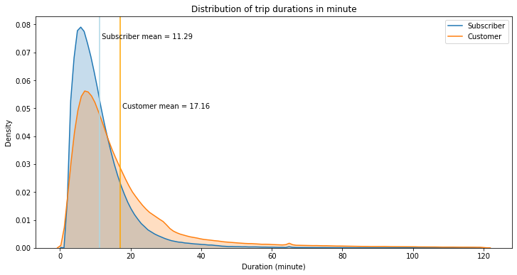

```python
time_sub = df_trim.query('user_type=="Subscriber"').duration.rename('Subscriber')
time_cus = df_trim.query('user_type=="Customer"').duration.rename('Customer')

plt.figure(figsize=(12,6))
sb.kdeplot(time_sub, shade=True);
sb.kdeplot(time_cus, shade=True);

plt.axvline(x=time_sub.mean(), color='lightblue')
plt.text(time_sub.mean(), 0.075,' Subscriber mean = {:.2f}'.format(time_sub.mean()))

plt.axvline(x=time_cus.mean(), color='orange')
plt.text(time_cus.mean(), 0.05, ' Customer mean = {:.2f}'.format(time_cus.mean()))
plt.title('Distribution of trip durations in minute')
plt.ylabel('Density')
plt.xlabel('Duration (minute)');
```

It can be seen that subscribers have a more concented time distribution. On average, customers spent more time on each trip. This finding is consistent with previous resutls. Subscribers usually take bikes to companies or schools, while customers may ride bikes to explore the city.

## Multivariate Exploration

Here, we further explore whether the daily trip pattern can vary across a week. For example, we find there are obvious morning peak and evening peak on an average day. However, whether this pattern carries to weekends is not obvious.

```python
cat_means = df_trim.groupby(['hour', 'day']).count().start_time.rename('count').reset_index().\
                    pivot(index = 'day', columns = 'hour', values = 'count')
cat_means = cat_means.apply(lambda x: x/x.sum()*100, axis=1)
cat_means
```

| hour day | 0 | 1 | 2 | 3 | 4 | 5 | 6 | 7 | 8 | 9 | ... | 14 | 15 | 16 | 17 | 18 | 19 | 20 | 21 | 22 | 23 |
| --- | --- | --- | --- | --- | --- | --- | --- | --- | --- | --- | --- | --- | --- | --- | --- | --- | --- | --- | --- | --- | --- |
| 0 | 0.382658 | 0.229173 | 0.164373 | 0.102382 | 0.171221 | 0.614817 | 2.402369 | 6.213495 | 12.007102 | 8.582322 | ... | 3.808843 | 4.642823 | 7.714097 | 12.857414 | 10.041479 | 6.235446 | 3.773545 | 2.396047 | 1.457226 | 0.767072 |
| 1 | 0.359173 | 0.218157 | 0.152972 | 0.095648 | 0.154773 | 0.657910 | 2.593478 | 6.743535 | 12.453609 | 8.835023 | ... | 3.513602 | 4.269289 | 7.469578 | 12.727288 | 10.003439 | 6.187333 | 3.889153 | 2.590203 | 1.640926 | 0.828734 |
| 2 | 0.412942 | 0.254864 | 0.172703 | 0.096622 | 0.147233 | 0.639050 | 2.466150 | 6.341856 | 12.004897 | 8.607368 | ... | 3.571710 | 4.553372 | 7.614368 | 12.604673 | 10.062442 | 6.287794 | 3.909228 | 2.695379 | 1.727192 | 0.896214 |
| 3 | 0.428688 | 0.236833 | 0.163559 | 0.100916 | 0.157344 | 0.597153 | 2.389921 | 6.337248 | 11.838548 | 8.711140 | ... | 3.690704 | 4.511442 | 7.587655 | 12.367333 | 9.854253 | 6.152263 | 3.972679 | 2.825151 | 1.864570 | 1.049393 |
| 4 | 0.567107 | 0.317012 | 0.197541 | 0.124034 | 0.171011 | 0.565756 | 2.086604 | 5.624266 | 11.202062 | 8.668497 | ... | 4.477884 | 5.551603 | 8.614254 | 11.637869 | 8.705167 | 5.360483 | 3.286553 | 2.364919 | 1.868954 | 1.333784 |
| 5 | 1.378974 | 0.944306 | 0.619693 | 0.273372 | 0.200170 | 0.255197 | 0.593441 | 1.315364 | 2.776628 | 4.635959 | ... | 9.013439 | 8.763038 | 8.411668 | 7.666270 | 6.484941 | 5.118335 | 3.727244 | 2.868004 | 2.314193 | 1.772246 |
| 6 | 1.364005 | 0.968259 | 0.674104 | 0.324387 | 0.216530 | 0.292793 | 0.529750 | 1.133312 | 2.305027 | 4.235825 | ... | 9.335592 | 9.231004 | 8.862221 | 8.050300 | 6.754386 | 5.188014 | 3.696269 | 2.637585 | 1.779907 | 1.149381 |

7 rows × 24 columns

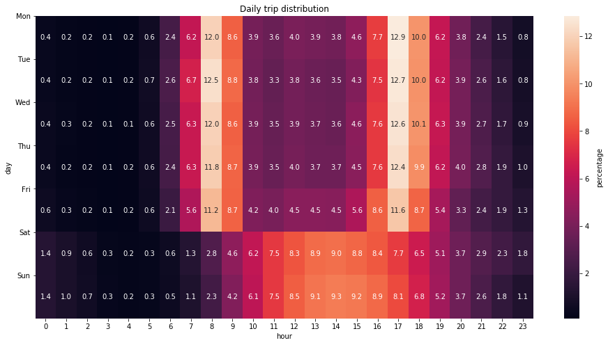

```python
plt.figure(figsize=(16,8))
sb.heatmap(cat_means, annot = True, fmt = '.1f',
           cbar_kws = {'label' : 'percentage'})
plt.title('Daily trip distribution')
plt.yticks(range(7), ['Mon','Tue','Wed','Thu','Fri','Sat','Sun'], rotation=0);
```

This heatmap verifies our guess: the morning peak and evening peak disappear on weekends!

Next, let's if this finding changes for different user types.

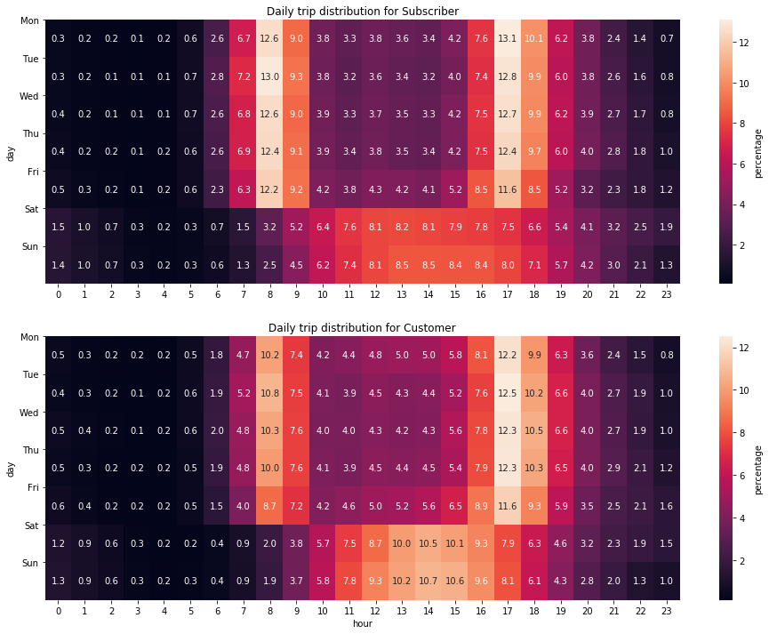

```python
cat_means_s = df_trim.query('user_type=="Subscriber"').groupby(['hour', 'day']).count().\
                      start_time.rename('count').reset_index().\
                      pivot(index = 'day', columns = 'hour', values = 'count')
cat_means_s = cat_means_s.apply(lambda x: x/x.sum()*100, axis=1)

plt.figure(figsize=(16,12))
plt.subplot(2,1,1)
sb.heatmap(cat_means_s, annot = True, fmt = '.1f',
           cbar_kws = {'label' : 'percentage'})
plt.title('Daily trip distribution for Subscriber')
plt.yticks(range(7), ['Mon','Tue','Wed','Thu','Fri','Sat','Sun'], rotation=0);
plt.xlabel('')

cat_means_c = df_trim.query('user_type=="Customer"').groupby(['hour', 'day']).count().\
                      start_time.rename('count').reset_index().\
                      pivot(index = 'day', columns = 'hour', values = 'count')
cat_means_c = cat_means_c.apply(lambda x: x/x.sum()*100, axis=1)

plt.subplot(2,1,2)
sb.heatmap(cat_means_c, annot = True, fmt = '.1f',
           cbar_kws = {'label' : 'percentage'})
plt.title('Daily trip distribution for Customer')
plt.yticks(range(7), ['Mon','Tue','Wed','Thu','Fri','Sat','Sun'], rotation=0);
```

It seems the two patterns are very similar. Thus, the morning peak and evenin peak exist for both Subscribers and Customers on weekdays; however, the peaks are gone during weekends.

## Time Series Plot

Finally, let's see how this bike-sharing business is affected by the COVID 19 outbreak.

```python
# df_trim['time'] = pd.PeriodIndex(df_trim.start_time, freq='d')
df_trim['week'] = pd.PeriodIndex(df_trim.start_time, freq='w') # weekly frequency is smoother
```

```python
trips_by_week = df_trim.query('start_time>"2019-12-31"').groupby('week')['start_time'].count()
```

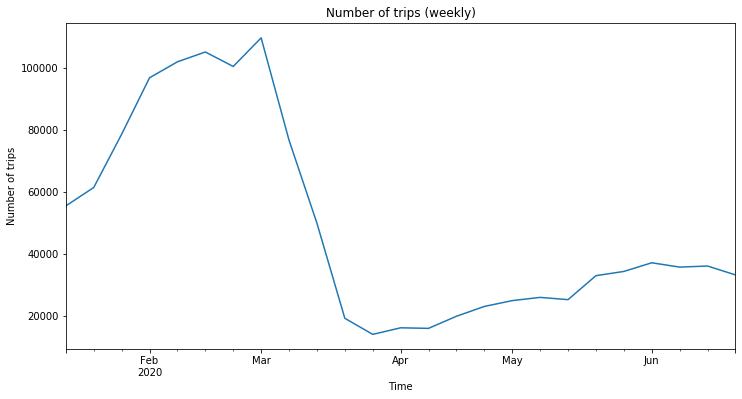

```python
plt.figure(figsize=(12,6))
trips_by_week[1:-1].plot()
plt.ylabel('Number of trips')
plt.xlabel('Time')
plt.title('Number of trips (weekly)');
```

```python
duration_by_week = df_trim.query('start_time>"2019-12-31"').groupby('week')['duration'].mean()
```

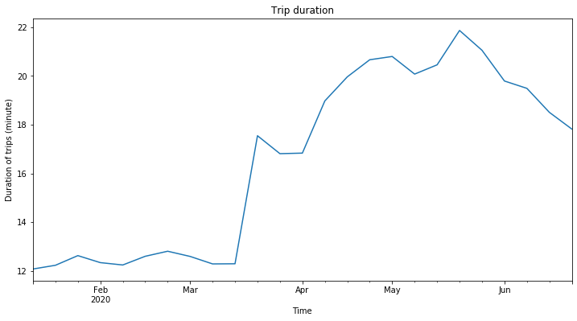

```python
plt.figure(figsize=(12,6))
duration_by_week[1:-1].plot()
plt.ylabel('Duration of trips (minute)')
plt.xlabel('Time')
plt.title('Trip duration');
```

We can see that there is a huge drop in trips after the COVID-19 outbreak; meanwhile, the average trip length has gone up.